# Week 11 - Day 03 Homework

```r
library(tidyverse)
library(factoextra)
library(cluster)
library(dendextend)
library(corrplot)
library(broom)

customers <- read_csv("data/mall_customers.csv")
```

| CustomerID | Gender | Age | Annual Income (k$) | Spending Score (1-100) |
| --- | --- | --- | --- | --- |
| 1 | Male | 19 | 15 | 39 |
| 2 | Male | 21 | 15 | 81 |
| 3 | Female | 20 | 16 | 6 |
| 4 | Female | 23 | 16 | 77 |
| 5 | Female | 31 | 17 | 40 |
| 6 | Female | 22 | 17 | 76 |

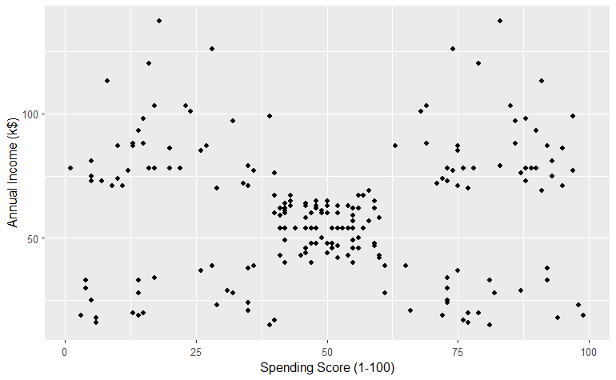

a lot of customers seem to be spread into around 5 groups

High Income, High Spending Low Income, High Spending Mid Income, Mid Spending Low Income, Low Spending High Income, Low Spending

Some outliers, might need to be scaled? Also columns are badly named

| customer_id | gender | age | annual_income_k | spending_score_1_100 | annual_income_scaled | spending_score_scaled |
| --- | --- | --- | --- | --- | --- | --- |
| 1 | Male | 19 | 15 | 39 | -1.73464625 | -0.433713114 |
| 2 | Male | 21 | 15 | 81 | -1.73464625 | 1.192711064 |
| 3 | Female | 20 | 16 | 6 | -1.69657236 | -1.711617825 |
| 4 | Female | 23 | 16 | 77 | -1.69657236 | 1.037813523 |
| 5 | Female | 31 | 17 | 40 | -1.65849848 | -0.394988729 |
| 6 | Female | 22 | 17 | 76 | -1.65849848 | 0.999089138 |
| 7 | Female | 35 | 18 | 6 | -1.62042459 | -1.711617825 |
| 8 | Female | 23 | 18 | 94 | -1.62042459 | 1.696128071 |
| 9 | Male | 64 | 19 | 3 | -1.58235070 | -1.827790981 |
| 10 | Female | 30 | 19 | 72 | -1.58235070 | 0.844191597 |

[output cut: 190 more lines]

```r
# clustered_customers <- customers %>%
#   kmeans(centers = )
# no not yet
```

```r
max_k = 20

k_clusters <- k_clusters <- tibble(k = 1:max_k) %>%
  mutate(kclust = map(k, ~kmeans(customers, centers = .x, nstart = 25)),
         glanced = map(kclust, glance),
         augmented = map(kclust, augment, customers))

customers_clusterers <- k_clusters %>%
  unnest(glanced)
```

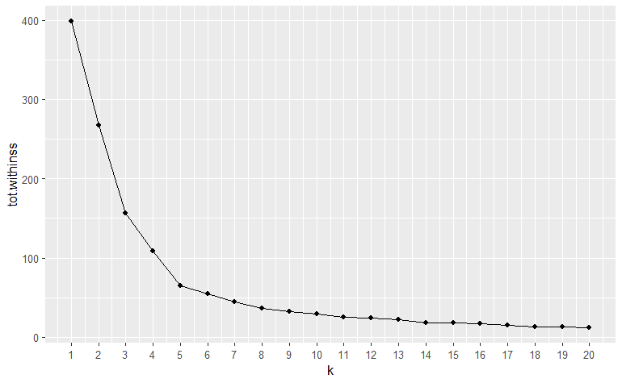

Checking another couple methods to make sure

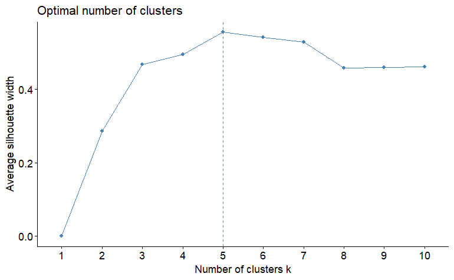

Looks like 5 clusters is optimal

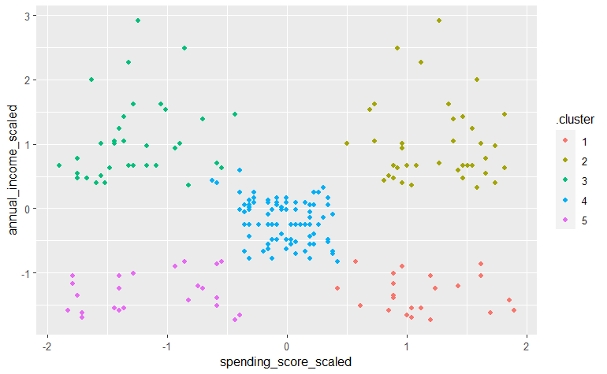

4. Clustering may be appropriate, as there is definite groups within this data - Some are more spread out that others, but there is a pattern.
5. Cluster 2 is the high income and high spending score cluster - These might be worth targeting for an advertising campaign, but seeing as they are already spending, it might not be quite as profitable than targeting another cluster.

Cluster 4 is the mid range, average income, average spending. This might be a good target for marketing, as they are already spending, just not as much, and they have more income to fund said spending